# Raport 1

Amelia Olejniczak

2024-02-28

# 1 Wprowadzenie

Przedstawiony niżej raport dotyczy analizy zarobków w USA w 2000 roku na podstawie ankiety z Bureau of Labor Statistics wykonanej na grupie n = 55899 osób (w tym 26685 kobiet i 29214 mężczyzn) w wieku od 25 do 65 lat.

# 2 Wstępna analiza

Aby rozpocząć analizę, wykonam histogram przedstawiający rozkład wszystkich zarobków zawartych w tabeli z danymi. Aby histogram był czytelny, sporządzam go na maksymalnym przedziale, gdzie szerokość słupków wynosi 7.5 tys. $. Dzięki temu unikniemy zarówno zbyt szerokich słupków, które mogą wpłynąć na mniej dokładne wnioski, jak i zbyt wąskich, które sprawią, że większość informacji będzie niemożliwa do zauważenia.

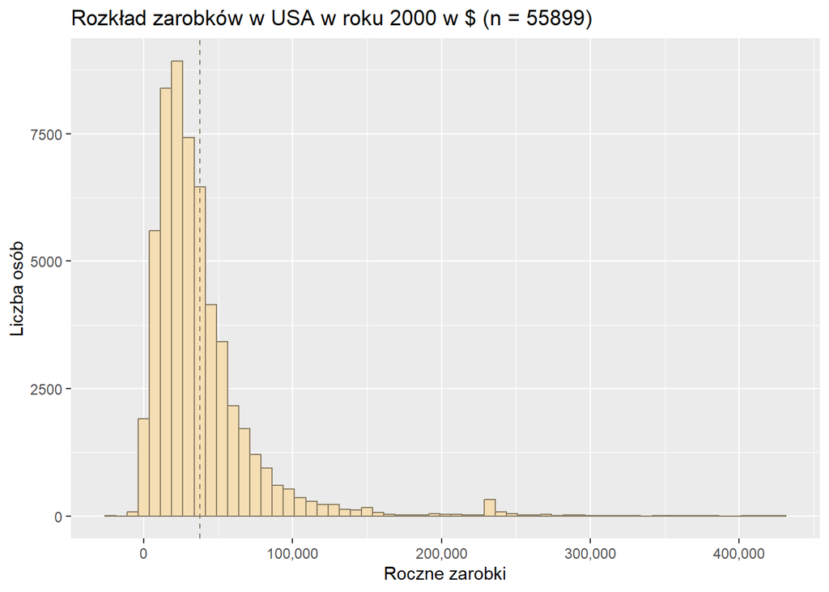

Powyższy histogram przedstawia rozkład zarobków w USA w roku 2000. Na pierwszy rzut oka można stwierdzić, że wykres ma kształt asymetryczny skośny w prawo, co oznacza, że zarówno średnia, jak i mediana będą bliżej minimalnej niż maksymalnej wartości. Histogram nie zaczyna się w zerze, z czego wynika, że w tabeli z danymi znajdują się zarobki mniejsze od zera. Można je rozumieć jako długi pewnej niewielkiej grupy osób. Z drugiej strony, wśród wysokich zarobków, gdzie liczba osób zbliża się do zera, następuje nagły wzrost dla wartości około 230 tys. $. Obie te grupy przeanalizuję w późniejszej części raportu. Z tego wykresu można również odczytać dominantę, znajdującą się w słupku między 20 tys. a 27,5 tys. $, zatem wynosi około 23750. Na histogramie pojawia się również pionowa linia przerywana, oznaczająca średnią. Jej wartość (razem z wartościami minimalnymi i maksymalnymi, a także kwartylami i medianą) możemy odczytać z poniższej tabeli.

```
##        id             age                   education            sex
##  Min.   :    1   Min.   :25.00   podstawowe      : 2165   mężczyźni:29214
##  1st Qu.:13976   1st Qu.:34.00   niepełne średnie: 3682   kobiety  :26685
##  Median :27950   Median :41.00   średnie         :17704
##  Mean   :27950   Mean   :41.95   niepełne wyższe :15756
##  3rd Qu.:41925   3rd Qu.:50.00   licencjat       :10991
##  Max.   :55899   Max.   :65.00   magisterium     : 5601
##      salary                    sector      age_group
##  Min.   :-24998   sektor prywatny :40896   20s: 7396
##  1st Qu.: 17000   sektor publiczny: 9429   30s:17169
##  Median : 29717   samozatrudnienie: 5574   40s:16994
##  Mean   : 37865                            50s:11249
##  3rd Qu.: 46504                            60s: 3091
##  Max.   :425510
```

Powyższa tabela przedstawia podsumowanie wszystkich zebranych w ankiecie danych, tj. podstawowych statystyk zmiennych ilościowych oraz liczbę osób w każdej kategorii zmiennych jakościowych. Tymi drugimi zajmę się w pierwszej kolejności, aby dokładnie uświadomić sobie, z jaką grupą mamy do czynienia.

Zacznę od wieku. Liczba osób w różnych etapach życiowych jest do siebie zbliżona. Mniejsze liczby znajdują się wśród osób między 25 a 29 rokiem życia, a także powyżej 60 roku życia. Jest to całkiem zrozumiałe, biorąc pod uwagę fakt, że są to o połowę mniejsze przedziały od pozostałych. Poza tym w przypadku osób starszych jest to wiek przedemerytalny, zatem może być duża grupa osób już niezdolnych do pracy w tym wieku. Ludzie również są mniej chętni zatrudniać starsze osoby, wolą szukać nowych, młodych głów. W przypadku płci liczba badanych kobiet i mężczyzn jest zbliżona do siebie, natomiast jeśli chodzi o wykształcenie, to większość badanych ma wykształcenie średnie, niepełnie wyższe, bądź posiadają licencjat, natomiast znacznie mniej osób ma wykształcenie podstawowe, bądź niepełne średnie. Wynika to prawdopodobnie z faktu, że w przypadku niższego wykształcenia, trudniej jest znaleźć pracę. Nie ma także tak wielu osób posiadających magisterium, co powiązałabym z wysokimi kosztami studiowania w Stanach Zjednoczonych. Nie każdy może sobie pozwolić na kolejne dwa lata tak dużych wydatków. W sektorze zatrudnienia przewyższa zatrudnienie prywatnie, co stoi w zgodie z panującym w USA systemem ekonomicznym.

W przypadku własności samych zarobków, to najmniejszą wartością jest -24998 $, a największą 425510 $, co daje nam rozrzut równy 450508 $. Mediana wynosi 29717 $, a średnia 37865 $. Pierwszy i trzeci kwartyl mają wartości 17000 $ oraz 46504 $, co oznacza, że w tym przedziale znajduje się aż 50% próby, podczas gdy rozrzut międzykwartylowy to zaledwie 29503.5. Odchylenie standardowe wynosi 36158.03 $, a współczynnik zmienności 0.9549294, jest to więc silnie zróżnicowana próba. W przypadku zarobków, trudno o to, aby losowa grupa tak wielu osób miała zbliżone do siebie zarobki, zatem jest to jak najbardziej zrozumiałe.

Sporządzę teraz bazujący na tych danych wykres pudełkowy, aby wizualnie przedstawić powyższe statystyki.

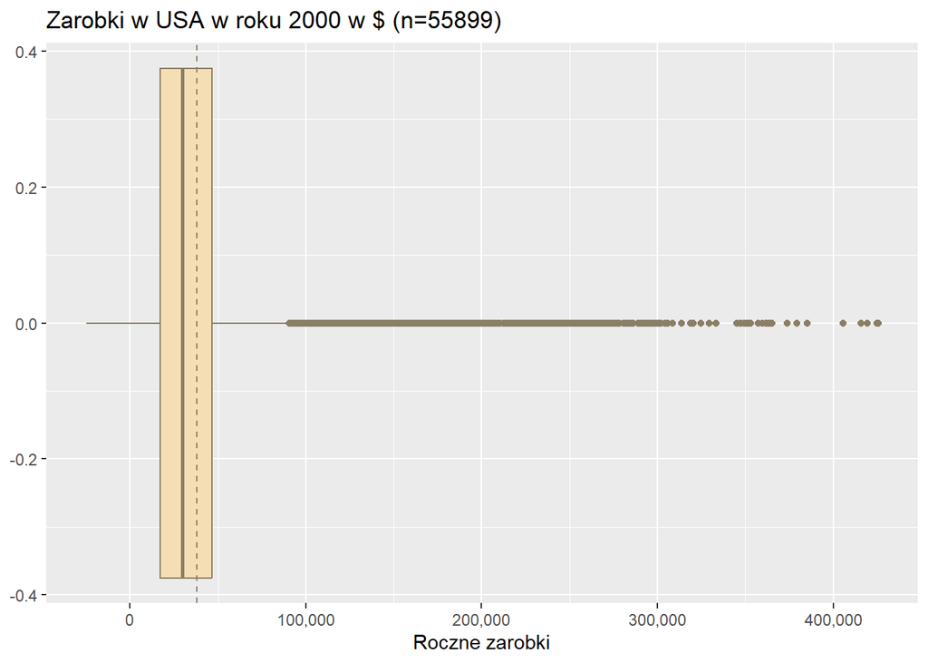

Na powyższym wykresie pojawia się wiele wartości odstających, w szczególności większych od 100000 $, co tylko dowodzi, że znaczna większość zarabia poniżej tej kwoty. Można na nim dobrze zauważyć różnicę między rozrzutem, a rozrzutem międzykwartylowym - pudełko jest naprawdę wąskie w stosunku do całej osi. Ponownie pojawia się przerywana linia wskazująca średnią wartość zarobków całej grupy. Aby lepiej widoczne było samo pudełko, sporządzę ten sam wykres, jednak bez widocznych wartości odstających, które znacząco zaburzają czytelność wykresu.

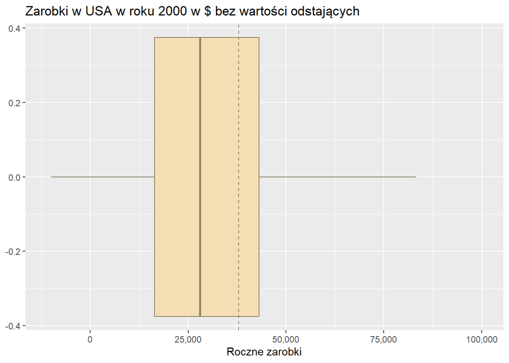

Patrząc na powyższy wykres, można wyraźnie zauważyć, że średnia wartość zbliża się raczej do trzeciego kwartyla, a nie mediany, co najpewniej jest spowodowane liczbą wartości odstających wśród dużych zarobków, podczas gdy wśród niewielkich wartości nie było zaznaczonych takich zarobków, które znacząco by się różniły od wszystkich wartości. Oznacza to, że średnia została mocno naruszona przez wartości odstające.

## 2.1 Wpływ zmiennych, różnych od płci, na zarobki

Aby przebadać wpływ sektora zatrudnienia, wykształcenia i wieku od zarobków, przeanalizuję wykresy słupkowe, gdzie wskażę średnie zarobki, a także mediany dla każdej z tych zmiennych. Płeć tymczasowo pominę i przeanalizuję w dalszej części raportu.

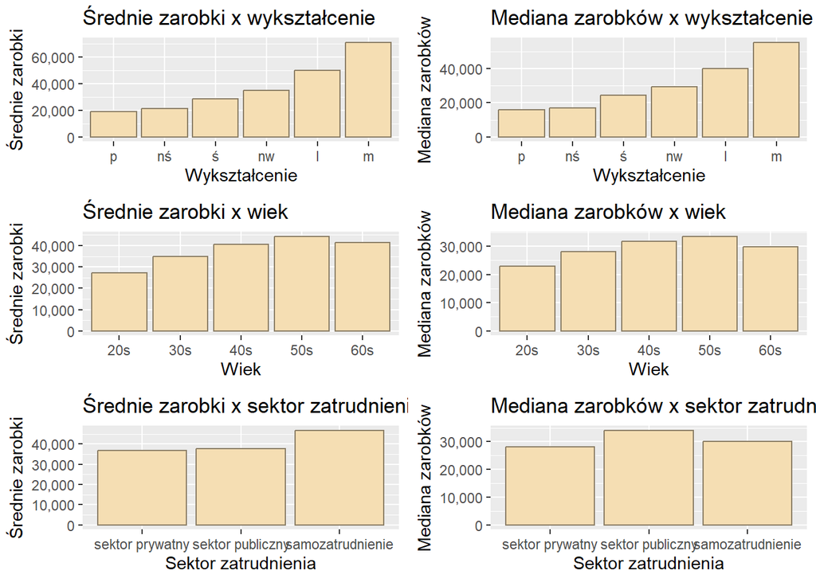

Pierwszy rząd wykresów przedstawiają średnie zarobki oraz medianę dla konkretnego poziomu wykształcenia. Dość oczywistym wnioskiem wydaje się, że im wyższe wykształcenie, tym wyższe zarobki. Oba wykresy są asymetryczne skośne w lewo, zatem poziom wykształcenia ma duże znaczenie na zarobki. Zarówno średnia jak i mediana w pierwszej i ostatniej grupie różnią się od siebie znacząco.

W przypadku wieku, na obu wykresach można zaobserwować wzrost do wieku 50 lat, a następnie spadek w momencie gdy zaczyna się mieć ich 60. Można się doszukiwać powodów takiego stanu rzeczy w rosnącym z wiekiem doświadczeniu zawodowym, a w późniejszych latach niewielki spadek może mieć wpływ z utratą zdolności do wykonywania części ze swoich poprzednich obowiązków, a także przedwczesną emeryturą, która jednak jest znacznie niższa od wysokości wynagrodzenia.

Natomiast w przypadku ostatniego rzędu wykresów, przedstawiającego sektor zatrudnienia, to największe średnie zarobki są dla osób samozatrudnionych, a najmniejsze w sektorze prywatnym, jednak bardzo zbliżone do sektora publicznego. Biorąc pod uwagę dużą liczbę osób zatrudnionych w sektorze prywatnym (aż 73% osób), możemy stwierdzić, że jego średnie zarobki bardzo zbliżone do średnich zarobków ogółem nie są zaskakujące. Ciekawy jest jednak fakt, że mediana zarobków jest największa w sektorze publicznym. Prawdopodobnie wynika to z tego, że w tym sektorze zarobki mają w dużej mierze dość podobne do siebie wartości. W przypadku zarówno samozatrudnienia, jak i sektora prywatnego, mogą tam się pojawić zarówno bardzo małe liczby, jak i bardzo duże, z czego może wynikać na przykład bardzo wysoka średnia właśnie osób samozatrudnionych.

## 2.2 Analiza długów

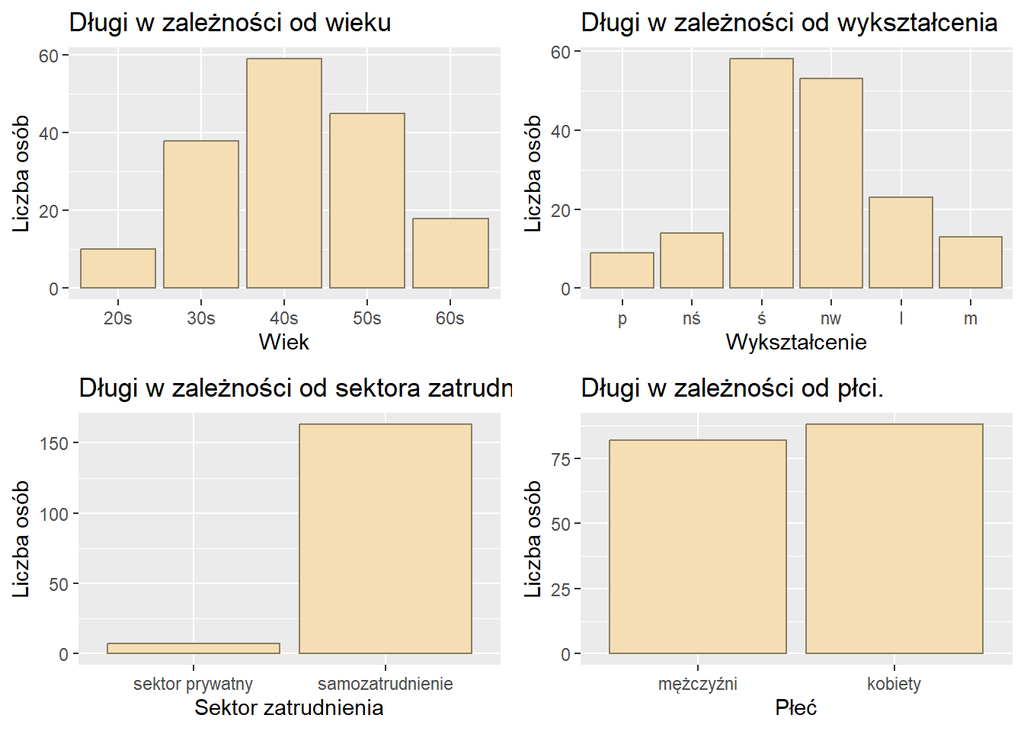

W lewym górnym rogu pojawia się wykres analizujący wiek tej grupy osób. Już na pierwszy rzut oka widać, że ten wykres ma kształt symetryczny, więc najwięcej osób ma długi w wieku około 40 lat, zarówno wcześniej jak i później liczba osób maleje. Może to mieć związek z chęcią zakupu mieszkania. Innym prawdopodobnym tokiem zdarzeń jest nagła utrata stałych dochodów, która może się zdarzyć.

W przypadku wykształcenia z analizy wykresu w prawym górnym rogu, większość osób plasujących się w ujemnych wartościach ma wykształcenie średnie, wyższe lub niepełne wyższe. Wynika to prawdopodobnie w dużym stopniu z kosztów studiowania w Stanach Zjednoczonych, gdzie pójście na studia wiąże się najczęściej z braniem kredytów, których bardzo często nie udaje się spłacić w całości i ciągną się one za ludźmi przez następne lata. Osoby ze średnim wykształceniem mogą próbować założyć własne działalności właśnie po to, aby uniknąć studiów i nie zawsze musi się to skończyć sukcesem.

Jeśli chodzi o wykres w lewym dolnym rogu, przedstawiający liczbę osób mających długi rozłożony na sektor zatrudnienia, nie jest on zaskakujący. Znacząca większość osób mających długi jest samozatrudniona. Najbardziej prawdopodobnie są to firmy, gdzie osoby nie były w stanie spłacić kosztów ich utrzymania w pełni.

Wykres w zależności od płci pokazuje, że kobiety mają częściej długi niż mężczyźni. Różnica jest jednak na tyle niewielka, że nie powinno się wnioskować takiej zależności. Ciekawy jednak fakt można spostrzec, gdy spojrzy się na wykres przedstawiający średnie wartości.

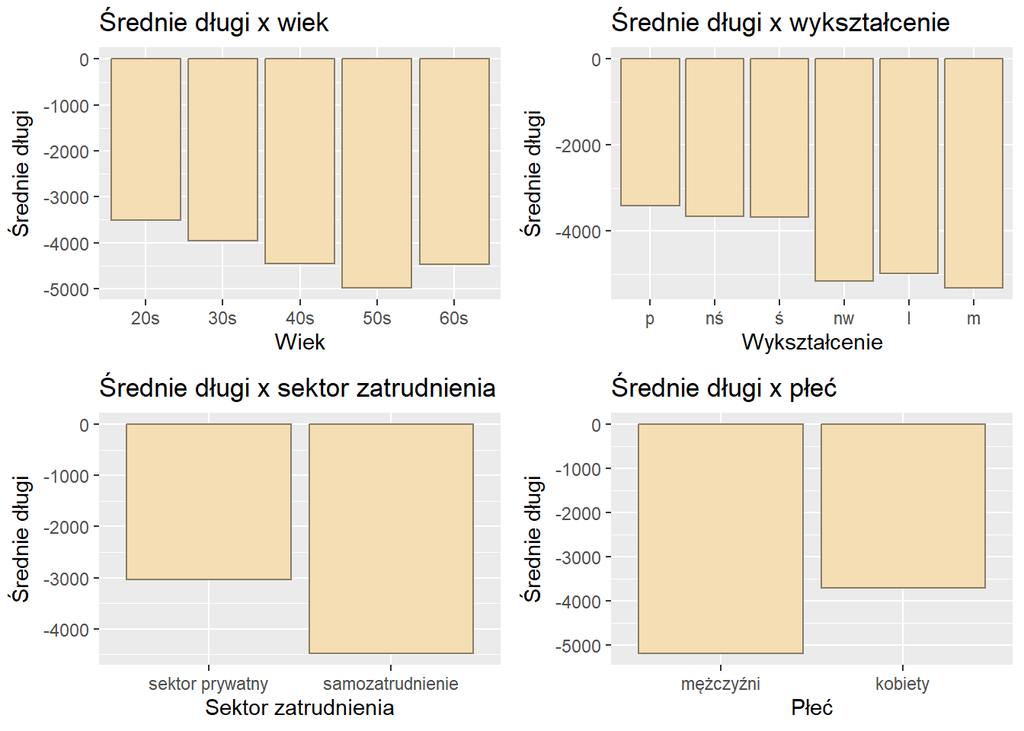

W przypadku wykształcenia widać jedynie, że długi w przypadku wysokiego wykształcenia są znacznie wyższe, co, znów, jest spowodowane naprawdę wysokimi kosztami studiów w Stanach Zjednoczonych.

Najciekawszy jest jednak wykres średnich długów w zależności od płci. Bazując na nim można zobaczyć, że mimo że kobiety w naszej próbie częściej miały długi, to średnio mężczyźni mieli te długi większe i to aż o 1,5 tys. $.

```
##     Min.  1st Qu.   Median     Mean  3rd Qu.     Max.
## -24998.0  -7376.2  -3799.0  -4429.9   -994.8     -1.0
```

Powyższa tabela pokazuje maksymalną oraz minimalną wartość długów, gdzie minimalna wartość jest taka sama jak minimalna wartość całej tabeli danych, a maksymalna to jedynie -1 $, co jest prawdopodobne, gdyż banki w Stanach zezwalają na pożyczkę jedynie 1 $. Mediana wynosi -3799 $, natomiast średnia -4429.9 $. Rozrzut wynosi 2.4997^{4} $, natomiast rozrzut międzykwartylowy (gdzie pierwszy i trzeci kwartyl to kolejno -7376.2 $ oraz -994.8 $) to 6381.4 $. Odchylenie standardowe wynosi 3912.166 $, a współczynnik zmienności 0.8831285, więc dalej mamy do czynienia ze zróżnicowaną grupą, co jest charakterystyczne dla analizy zarobkowej.

## 2.3 Analiza wysokich wartości

W tym momencie zajmę się analizą wyjątkowo wysokich zarobków. Nie będę jednak brała pod uwagę wszystkich wysokich wartości, ponieważ byłby to zbyt duży rozrzut, a grupa między 225 a 250 tys. $, przy której następuje nagły wzrost słupka, będzie dobrym reprezentantem wysokich wynagrodzeń. Jest to grupa licząca aż 464 osoby, zatem stanowczo więcej osób zarabia wysokie stawki niż ma długi, co jest pozytywnym wnioskiem. Analiza tej części będzie wyglądała podobnie do analizy długów, jednak ominę wnioskowanie ze statystyk, ze względu na niewielki przedział zarobkowy.

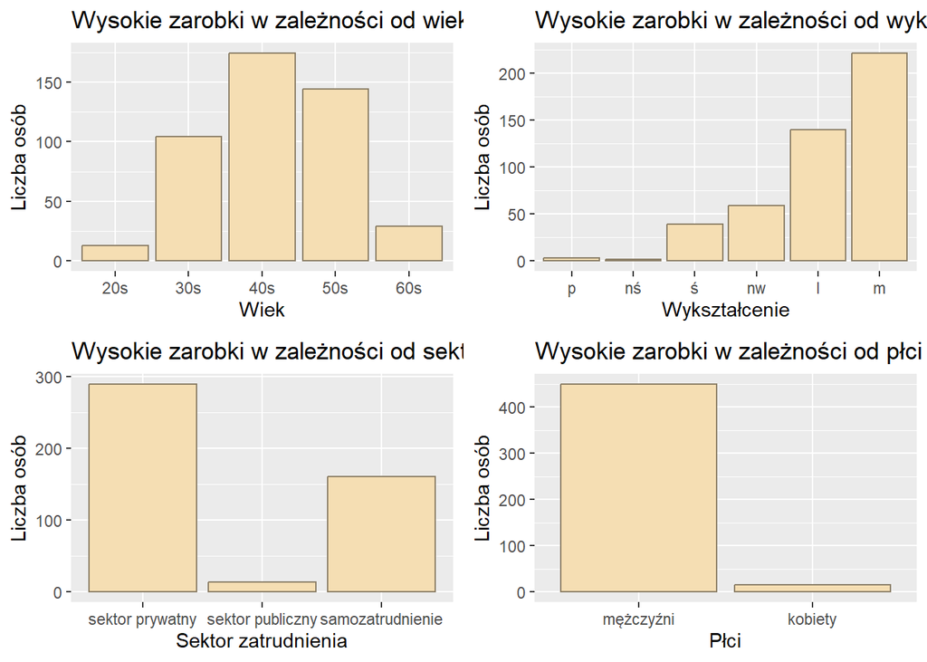

Zaczynając od wykresu wysokich zarobków a wieku, widzimy od razu, że jest podobny do poprzedniego przypadku. Jego kształt jest również symetryczny. Prawdopodobnie wynika to z faktu, że znaczna większość osób, które zarabiają duże kwoty, to osoby z dużym doświadczeniem zawodowym, które zdobywa się z wiekiem.

Wykształcenie również nie jest zaskakujące - im wyższe wykształcenie, tym łatwiej nam zdobyć lepiej płatną pracę, ponieważ dostajemy więcej ofert zawodowych i możemy wybierać te, które najbardziej nam odpowiadają. Z tego samego względu tak niewiele jest osób bez wysokiego wykształcenia, które tyle zarabiają. Nie ma zbyt wielu pracodawców, którzy chcieliby zatrudnić osobę bez studiów na tak dobrze płatne stanowisko, przez to, że nie opłaca im się to ze względu na koszty kursów, które musiałyby takie osoby odbyć.

W przypadku sektora zatrudnienia, najmniej osób jest w sektorze publicznym, co prawdopodobnie jest spowodowane faktem, że w tym przypadku zarobki są mało zróżnicowane, natomiast w sektorze prywatnym jest znaczna większość tak bardzo dobrze zarabiających osób. Jest to jednak również najliczniejsza grupa, więc nie ma pewności, czy nie był to jedynie przypadek.

Natomiast jeśli chodzi o płeć, to znacząca większość osób to mężczyźni. Pokazuje to nieco pesymistyczny obraz tego, że kobietom trudno było trafić na najlepiej płatne stanowiska, a na pewno dużo trduniej niż mężczyznom.

# 3 Analiza zarobkowa ze względu na płeć

Powyższe wnioskowanie jest dobrym wstępem do analizy zarobków ze względu na płeć. Warto zacząć je od sporządzenia podobnego histogramu jak na początku, jednak tym razem weźmiemy pod uwagę rozróżnienie płci. Sporządzę dwa histogramy nałożone na siebie, dzięki którym będzie łatwo można dostrzec różnice między zarobkami poszczególnych płci.

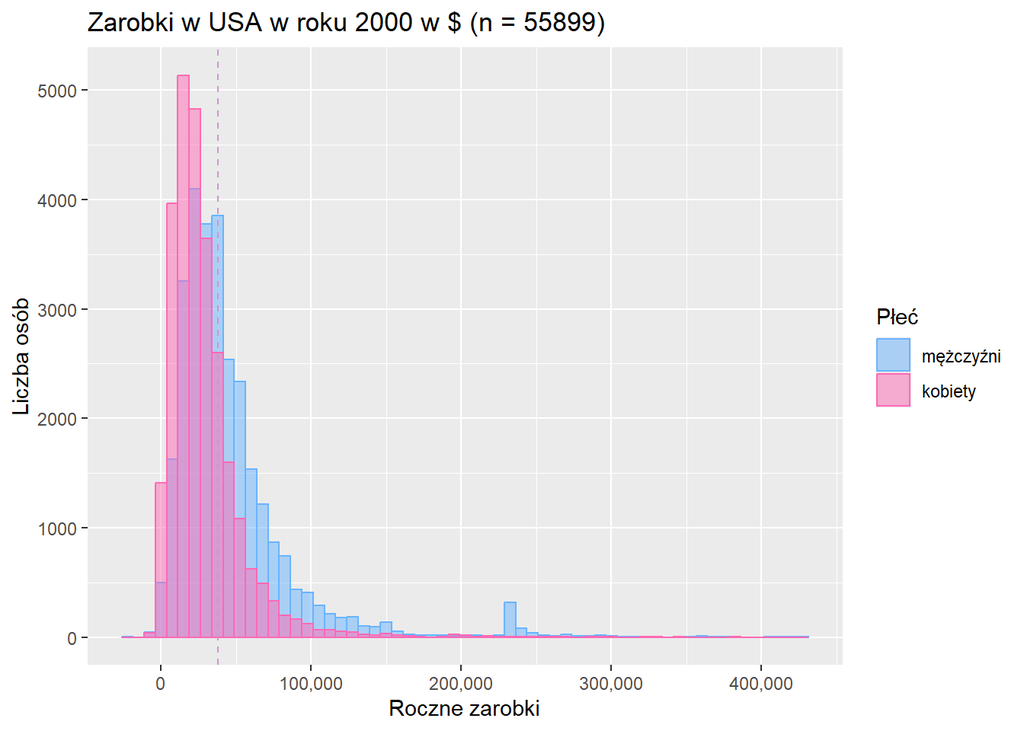

Na powyższym wykresie można zauważyć, że więcej kobiet niż mężczyzn znajduje się w przedziale do około 25 tys. $ rocznie i od tego miejsca to słupki niebieskie są wyższe. Gdy spojrzymy na przerywaną linię wyznaczającą średnią wartość zarobków, można zauważyć, że więcej kobiet niż mężczyzn zarabia poniżej średniej wartości, podczas gdy raczej mężczyźni niż kobiety plasują się powyżej tej linii przerywanej. Zatem nie byłoby przesadą powiedzenie, że kobiety zarabiają dużo mniej niż mężczyźni.

Aby dokładniej porównać te zarobki, sporządzę wykres pudełkowy zarobków kobiet i mężczyzn, najpierw ze wszystkimi wartościami odstającymi, aby zobaczyć ich zagęszczenie w zależności od płci

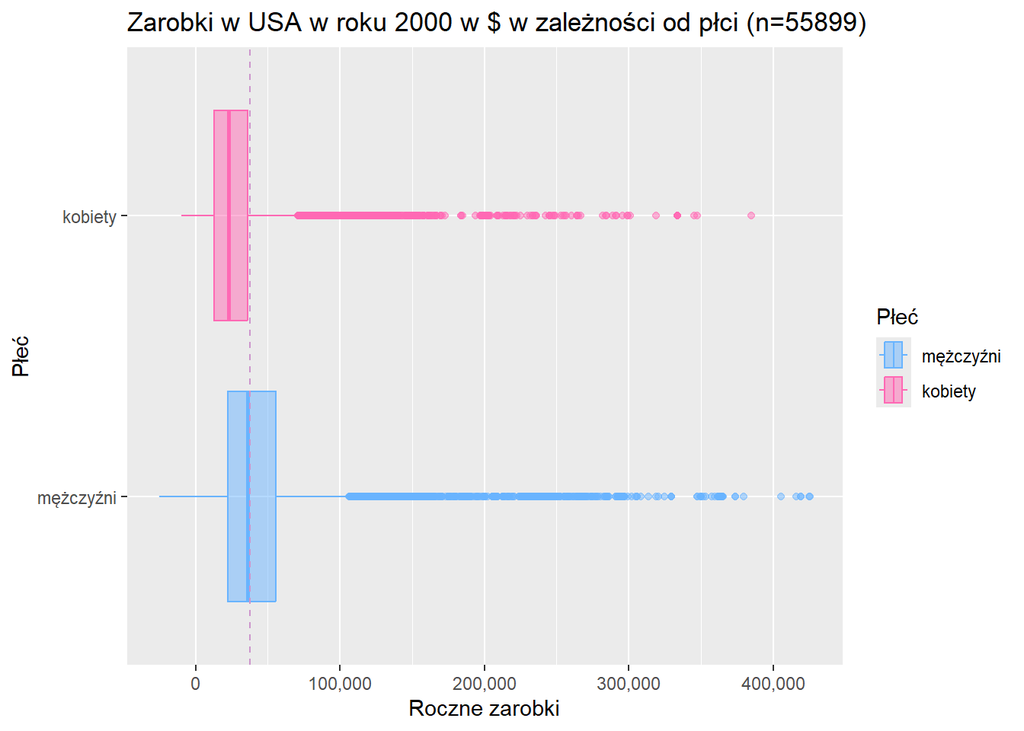

Powyższy wykres pudełkowy przedstawia medianę zarobków kobiet i mężczyzn wraz z wartościami odstającymi, aby dobrze zobrazować ich ilość względem płci. Widać, że wśród kobiet największa wartość jest mniejsza niż największa wartość wśród mężczyzn. Wartości odstających jest również u kobiet mniej, biorąc pod uwagę ich rzadsze uplasowanie na wykresie. Zatem kobiety rzadziej mają naprawdę wysokie wynagrodzenia. W szczególności możemy to zauważyć, patrząc na wartość 100 tys. $, które u kobiet już jest wartością odstającą, natomiast u mężczyzn znajduje się ona jeszcze w wąsie faktycznego wykresu.

Sporządzę teraz drugi wykres pudełkowy, aby poprawnie wnioskować na temat mediany i kwartyli, zarówno kobiet jak i mężczyzn.

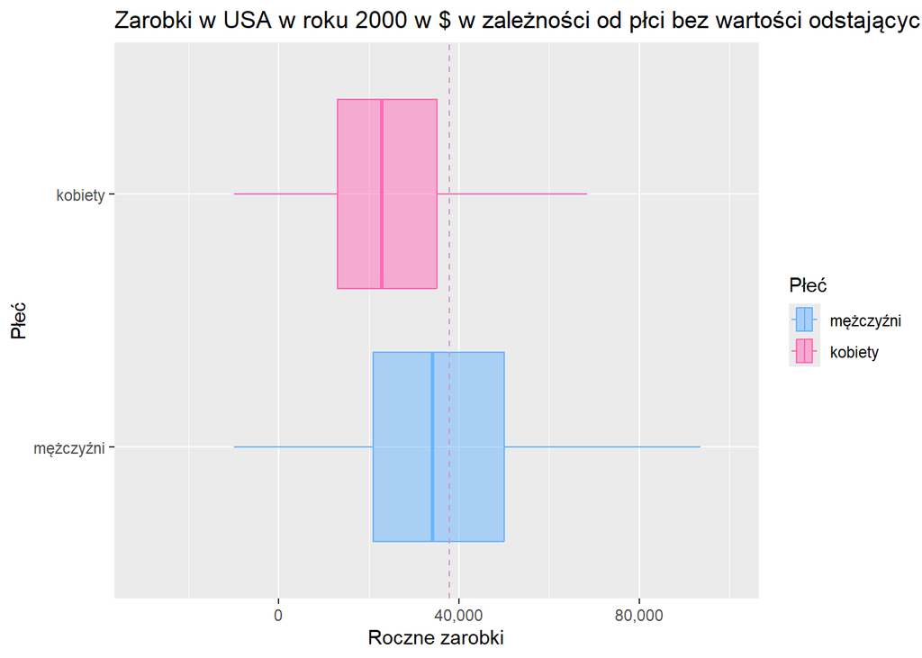

## 3.1 Analiza zarobków poszczególnych płci w zależności od wieku, wykształcenia oraz sektora zatrudnienia

W tym celu sporządzę teraz trzy wykresy słupkowe, które zaprezentują średnie zarobki kobiet i mężczyzn w zależności od różnych czynników możliwych do odczytania z tabeli danych. Nie będę oddzielnie analizować takich samych wykresów prezentujących medianę tych zarobków, ponieważ prezentują się one bardzo podobnie.

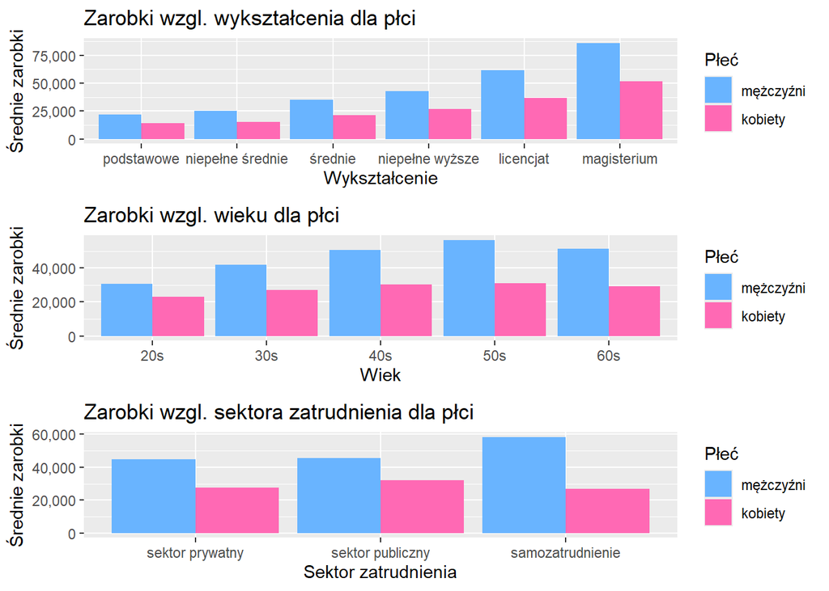

W przypadku wieku, ciekawy jest fakt, że różnica między słupkami u kobiet jest niewielka, podczas gdy u mężczyzn wyraźnie wzrasta. Można z tego wnioskować, że będąc kobietą, trudniej jest dostać awans czy podwyżkę bądź też że kobiety mniej chętnie zmieniają pracę z wiekiem, kiedy nabierają doświadczenia.

Jeśli chodzi o sektor, to poza faktem, że wszystkie słupki u kobiet są niższe niż u mężczyzn, warto się skupić na samozatrudnieniu. Średnia zarobków kobiet zatrudnionych w tym sektorze jest najniższa, podczas gdy u mężczyzn - najwyższa. Jest to spowodowane faktem, że o wiele mniej kobiet zakłada własne firmy, przez co jest mniejsza szansa na osiągnięcie dużego sukcesu i bardzo wysokich zarobków.

# 4 Przeciętne zarobki w Stanach Zjednoczonych w roku 2000

Jako przeciętne zarobki w Stanach zjednoczonych w roku 2000 uznaję medianę zarobków bez wartości odstających pojawiających się na wykresie pudełkowym. W takim przypadku do ich wyznaczenia nie będą wykorzystywane szczególne przypadki, a będziemy patrzeć jedynie na większość zbliżonych do siebie wartości, więc mediana będzie możliwie najmniej narażona na odstawanie od często występujących wartości, co rozumiałabym jako “przeciętną” wartość - to te zarobki, w pobliżu których najpewniej będą nasze, gdybyśmy zdecydowali się na pracę.

```
##    Min. 1st Qu.  Median    Mean 3rd Qu.    Max.
##   -9999   16000   27000   29567   40500   76004
```

Patrząc na powyższą tabelę, widzimy, że mediana ta wynosi 27 tys. $, co możemy uznać za przeciętne zarobki w USA.

# 5 Podsumowanie

Podsumowując rozważania, zarobki w Stanach są bardzo zróżnicowane, jednak można zauważyć pewne ich własności. Osoby w Stanach w 2000 roku zarabiały przeciętnie 27 tys. $, jednak zdarzały się wśród nich również długi, jak i bardzo wysokie wartości, w szczególności wśród nich takie, wynoszące około 240 tys. $. Na te drugie szanse są bardzo niewielkie w momencie, gdy jest się kobietą. Ogólna sytuacja dla kobiet również jest pesymistyczna - w każdej kategorii zarabiały one mniej niż mężczyźni.